# midterm project 531

3/6/2020

# Introduction

Consumer sentiment is a statistical measurement and economic indicator of the overall health of the economy as determined by consumer opinion. Consumer sentiment takes into account an individual’s feelings toward his or her current financial health, the health of the economy in the short-term and the prospects for longer-term economic growth.[1]

Consumer sentiment will change over time.If people are confident about the future they are likely to shop more, boosting the economy. In contrast, when consumers are uncertain about what lies ahead, they tend to save money and make fewer discretionary purchases. Gloomy sentiment weakens demand for goods and services, impacting corporate investment, the stock market, and employment opportunities, among other things.If people are confident about the future they are likely to shop more, boosting the economy. In contrast, when consumers are uncertain about what lies ahead, they tend to save money and make fewer discretionary purchases. Gloomy sentiment weakens demand for goods and services, impacting corporate investment, the stock market, and employment opportunities, among other things. [1]

In this project, we will analyze the monthly consumer sentiment over the past twenty-five years. Our goals are as follows:

1. despite consumer sentiment will change over time, however, we want to explore whether or not the consumer sentiment tends to move towards the mean value consumer sentiment in the midst of the fluctuations. we will also use spectrum to check the period and cycle of consumer sentiment.finally we will use model to predict future cosumer sentiment.
2. we will use various methods and models learnd in stats 531 and explore the fluctuations.

# Exploratory Data Analysis

The data used for this project is the consumer sentiment for the past 68 years from https://fred.stlouisfed.org/series/UMCSENT [2]. The consumer sentiment for the first of each month is recorded and used for the data, from 1952 to 2020

First, we will read in the data. There are 2 variable of 807 observations each. the variable “DATE” give us the date recording the consumer sentiment, the variable “UMCSENT” give us the consumer sentiment，however, we just need the last 25 years data, since there are some missing data in the longer time, besides, this data has less meaning for us. so there are only 301 data we need to analysis.

```
##           DATE UMCSENT
## 507 1995-01-01    97.6
## 508 1995-02-01    95.1
## 509 1995-03-01    90.3
## 510 1995-04-01    92.5
## 511 1995-05-01    89.8
## 512 1995-06-01    92.7
## 513 1995-07-01    94.4
## 514 1995-08-01    96.2
## 515 1995-09-01    88.9
## 516 1995-10-01    90.2
## 517 1995-11-01    88.2
## 518 1995-12-01    91.0
## 519 1996-01-01    89.3
## 520 1996-02-01    88.5
```

[output cut: 287 more lines]

```
##    Min. 1st Qu.  Median    Mean 3rd Qu.    Max.
##   55.30   81.20   91.20   88.64   97.00  112.00
```

let’s look the format of the date. The first column is the date, and the second column is consumer sentiment on that day. from the summary data, we see the mean data is 88.64, max data is 112, min data is 55.30.

then, we can plot the data to observe the trend. The red line is the mean value of the consumer sentiment

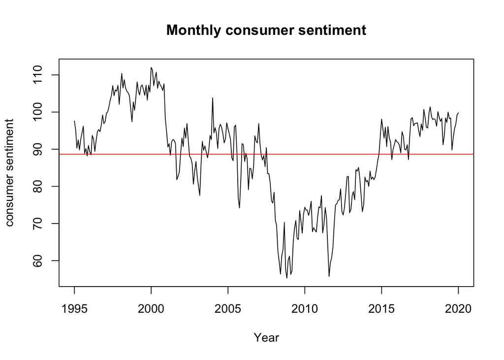

From the plot, we can see consumer sentiment fluctuates around the mean overall, around the year 2000, consumer sentiment reached the max value, aound 2010 , consumer sentiment is in the lowest. No matter at the biggest and lowest, they all return to the mean value gradually. from the plot, we can’t see obvious seasonality property of consumer sentiment.

# Data Smoothing

In this section, we will use Loess smoothing to take a look at the general trend of the consumer sentiment.

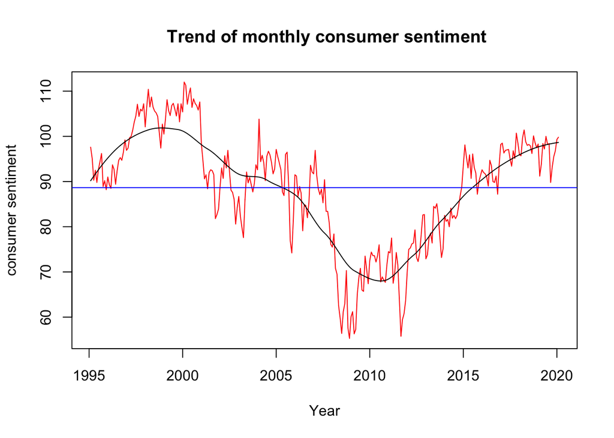

from the smoothing plot, we can find at frist the trend is increasing, and around 2010, the consumer sentiment is lowest. around 2000, the consumer sentiment is highest, but they all trend to the mean value

We now look at the dataset in terms of the low frequency component, which acts as the trend, the high frequency component, which acts as noise, and the cycles component. I decomposite the time series by different frequency

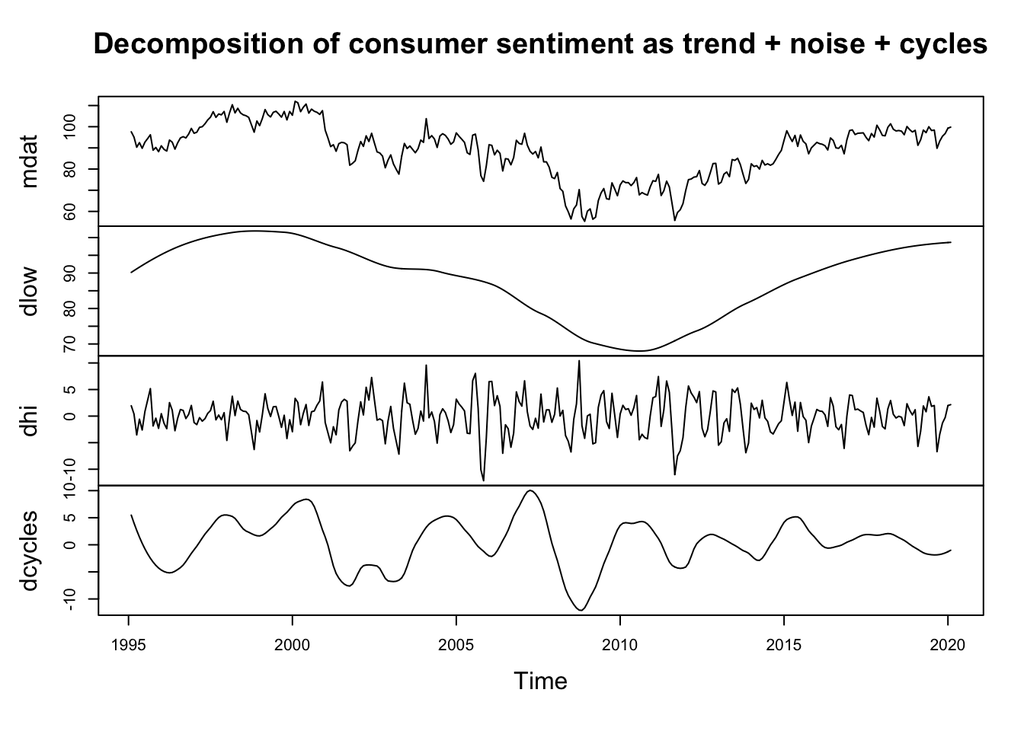

# Fitting an ARMA(p,q) model

from the analysis of the data, we can found although data is fluctuate, but it trend to reach the mean value of the consumer sentiment, it looks like staionary. and from the specturm and plot, we can’t found obvious period property of the data, so we first try to use arma model to analysis the data. Because there are some unstationay aound 2010, so later on we will use other model to better analysis the data.

An ARMA(p,q) equation is written as[3]

$$\phi(B)(Y_n-\mu)=\psi(B)\epsilon_n$$

then we will use ACF to choose the best value of p and q. The AIC of a model is :

$$AIC=-2 \times \ell(\theta^*) + 2D$$
where $\ell(\theta^**)$ is the log likelihood function $\mathscr{L}=f_{Y_{1:N}}(y^*_{1:N};\theta)$ and $D$ is the number of parameters. The second term $2D$ serves as a penalty for models with more parameters, in order to deal with the problem of overfitting. [3]

We will construct a table that displays the AIC values for the different ARMA(p,q) models

[output not shown]

then we use ARMA(4,3) to fit data and analysis.

```
##
## Call:
## arima(x = umcs, order = c(4, 0, 3))
##
## Coefficients:
##          ar1     ar2     ar3      ar4     ma1      ma2      ma3  intercept
##       0.0424  0.7544  0.6174  -0.4483  0.8538  -0.0766  -0.6951    90.6628
## s.e.  0.1440  0.0807  0.0766   0.1330  0.1221   0.1872   0.1208     5.8940
##
## sigma^2 estimated as 13.28:  log likelihood = -819.92,  aic = 1657.84
```

The equation is written as[3]
$$(X_n-\mu)-\phi_1(X_{n-1}-\mu)-\phi_2(X_{n-2}-\mu)-\phi_3(X_{n-3}-\mu)-\phi_4(X_{n-4}-\mu)=\epsilon_n+\theta_1\epsilon_{n-1}+\theta_2\epsilon_{n-2}+\theta_3\epsilon_{n-3}$$
we see that the mean $\mu=90.6628$, $\phi_1=0.0424$, $\phi_2=0.7544$, $\phi_3=0.6174$, $\theta_1=0.8538$, $\theta_2=-0.0766$, and $\theta_3=-0.6951$. the estimated variance for the error is 13.28.

## check casuality/invertibility of model

we can check the causality and invertibility of our model, to check wheter is suitable to use arma(4,3) model to fit the data.

In order for the model to be causal, we will need to check the roots of the AR polynomial $1-\phi_1z-\phi_2z^2-\phi_3z^3-\phi_4z^4$. to check whether the roots are outside the circle, if the roots are outside, we can prove the moodel is cansual

```r
abs(polyroot(c(1,0.0424,0.7544,0.6174,-0.4483)))
```

```
## [1] 0.8941717 1.2096297 0.8941717 2.3064123
```

we can see some roots are not ouside, so the model is not causal

In order for the model to be invertibility, we will need to check the roots of the MA polynomial $1+\theta_1z+\theta_2z^2+\theta_3z^3$. to check whether the roots are outside the circle, if the roots are outside, we can prove the moodel is cansual

```r
abs(polyroot(c(1,0.8538,-0.0766,-0.6951)))
```

```
## [1] 0.9999921 0.9999921 1.4386646
```

we can see some roots are not ouside, so the model is not vertible. so there are some problem of the arma(4,3) model, it is not reliable to use this model to predict the data.

## Diagnostics

We will now do diagnostics for the assumptions to see if the ARMA model is appropriate. first we can check whether the residuals are white noise

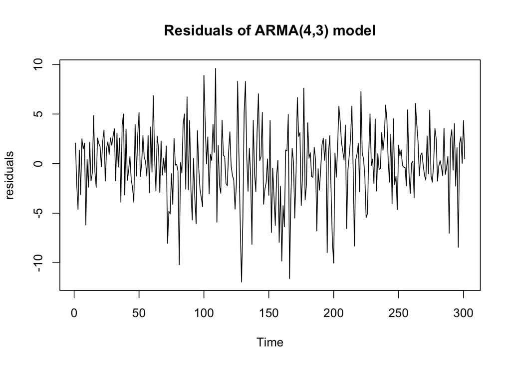

so the residuals’s mean value is around 0, and the variance is constant. so the model seems like statisfiy the white noise requirement.

then we can check ACF to verity whether the residuals are iid

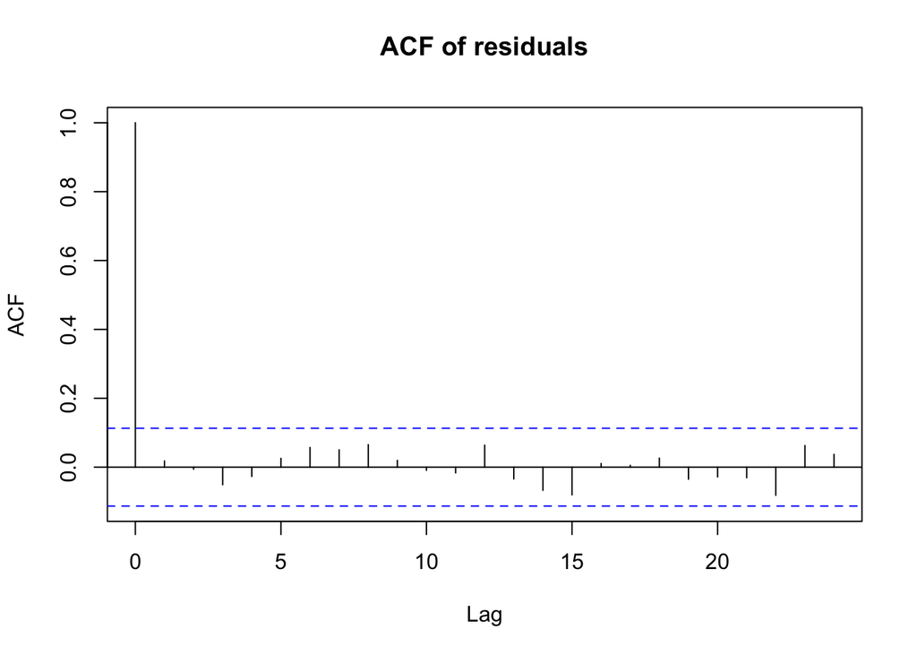

we can see there is no autocorrelation between different residuals. so it satisfy our expectation.

then we can assume the residual follow the normal distribution with mean value 0, variance 13.28. we can use qqplot to verify.

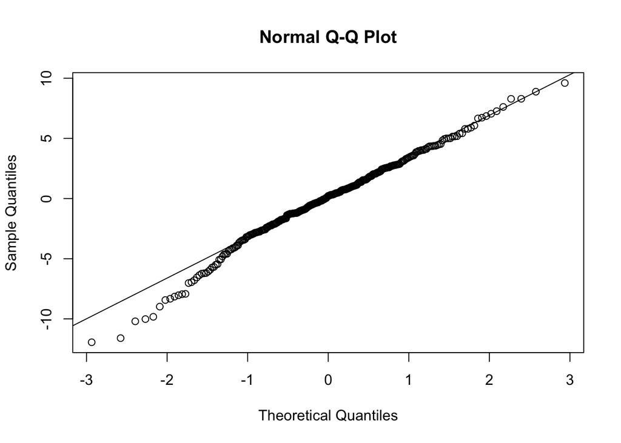

we can found that most of the residuals are on the qqline, it seems like satisfied the normal distribution.

# Spectrum Analysis

In this section, we will use spectrum analysis to find the period of the cycles component

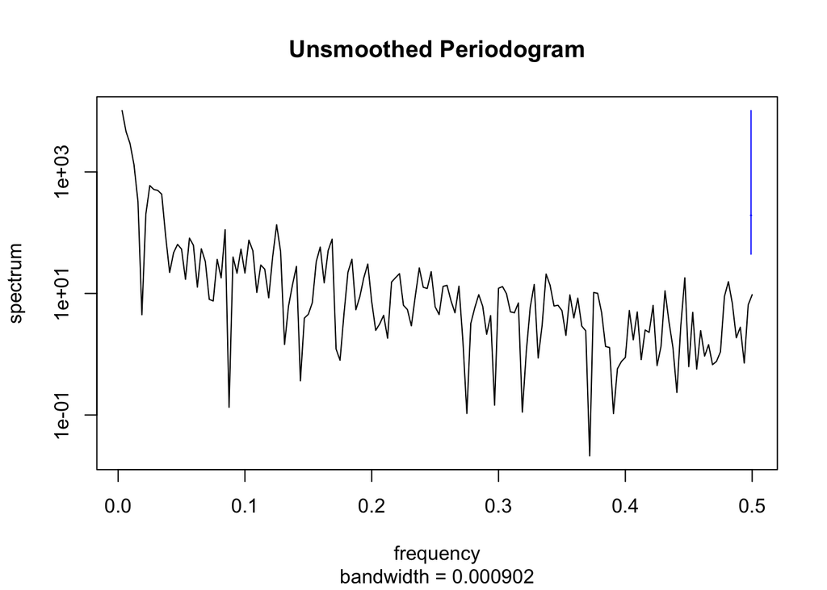

at the frequency 0, it has the highest spectrum. so we can’t find obvious cycle now.

then we use smoothed periodgram to check whether there is cycle.

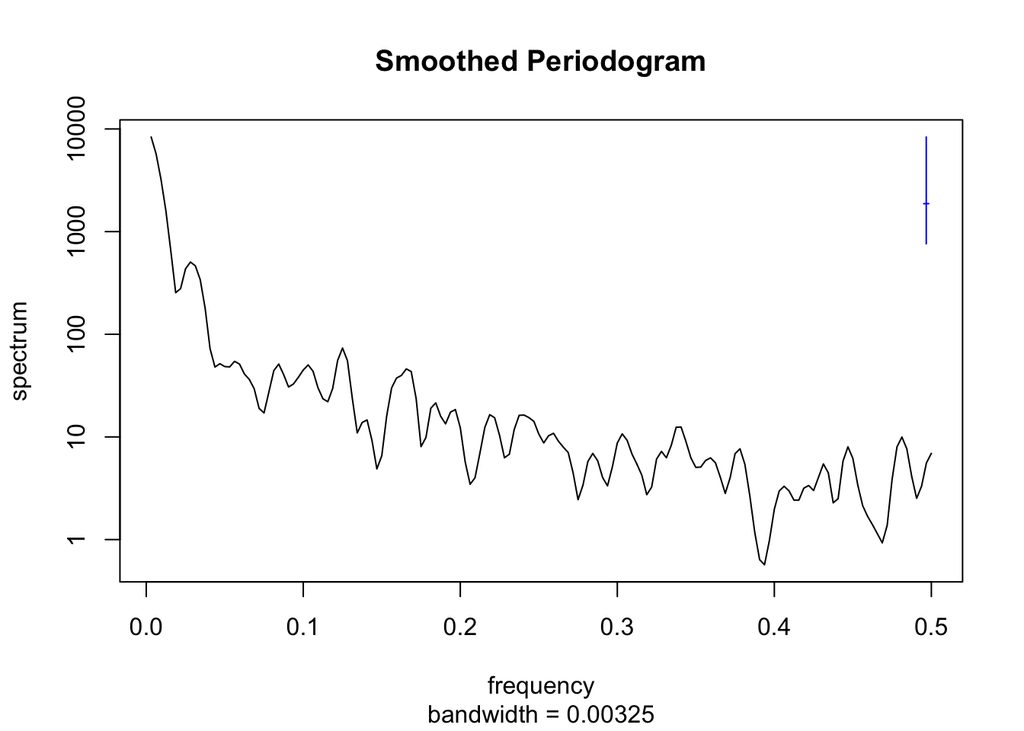

```r
smoothed$freq[which.max(smoothed$spec)]
```

```
## [1] 0.003125
```

# Fitting an SARIMA model

According to notes06, SARIMA$(0,1,1)\times(0,1,1)_{12}$ model is always used in monthly economic data. we can use this model to predict our data.[3]

```
##
## Call:
## arima(x = dat$UMCSENT, order = c(0, 1, 1), seasonal = list(order = c(0, 1, 1),
##     period = 12))
##
## Coefficients:
##           ma1     sma1
##       -0.1485  -0.9538
## s.e.   0.0721   0.0791
##
## sigma^2 estimated as 14.88:  log likelihood = -811.28,  aic = 1628.57
```

## Diagnostics

We will now do diagnostics for the assumptions to see if the SARIMA model is appropriate. first we can check whether the residuals are white noise

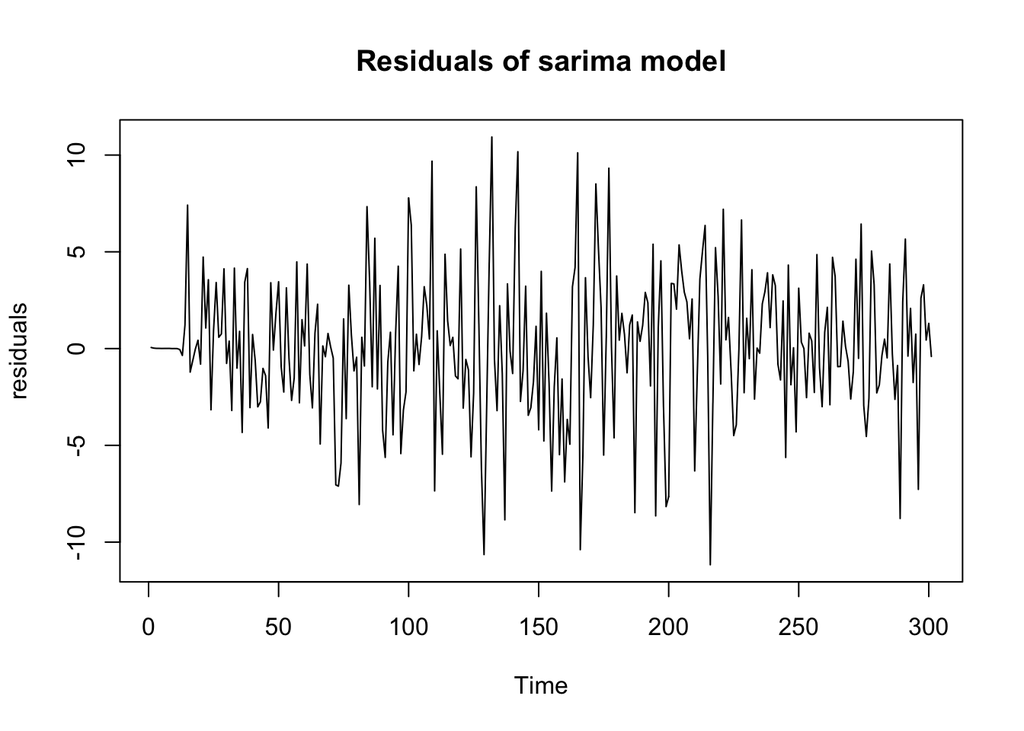

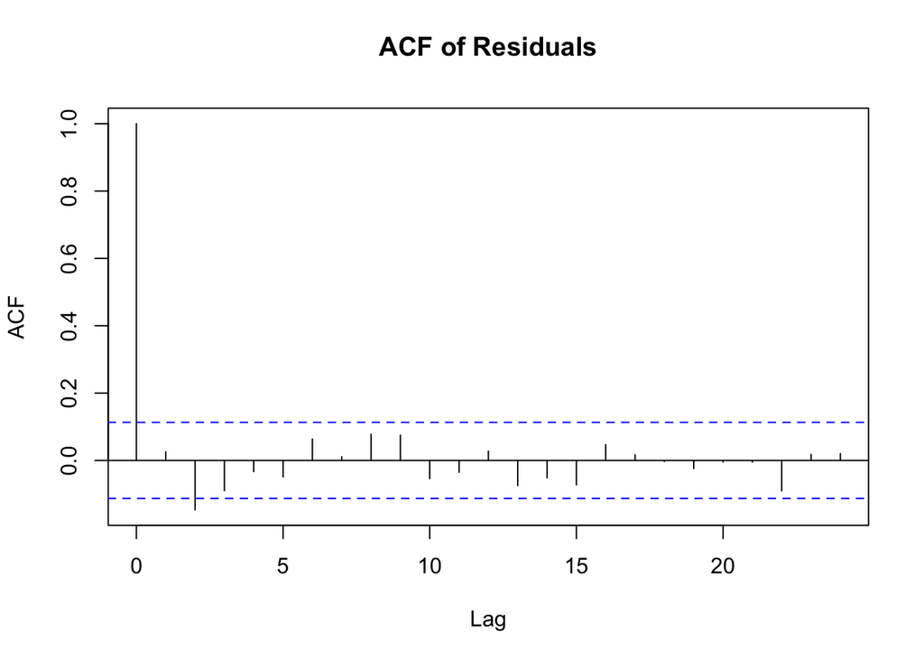

so the residuals’s mean value is around 0, and the variance is constant. so the model seems like statisfiy the white noise requirement.

then we can assume the residual follow the normal distribution with mean value 0, variance 14.88. we can use qqplot to verify.

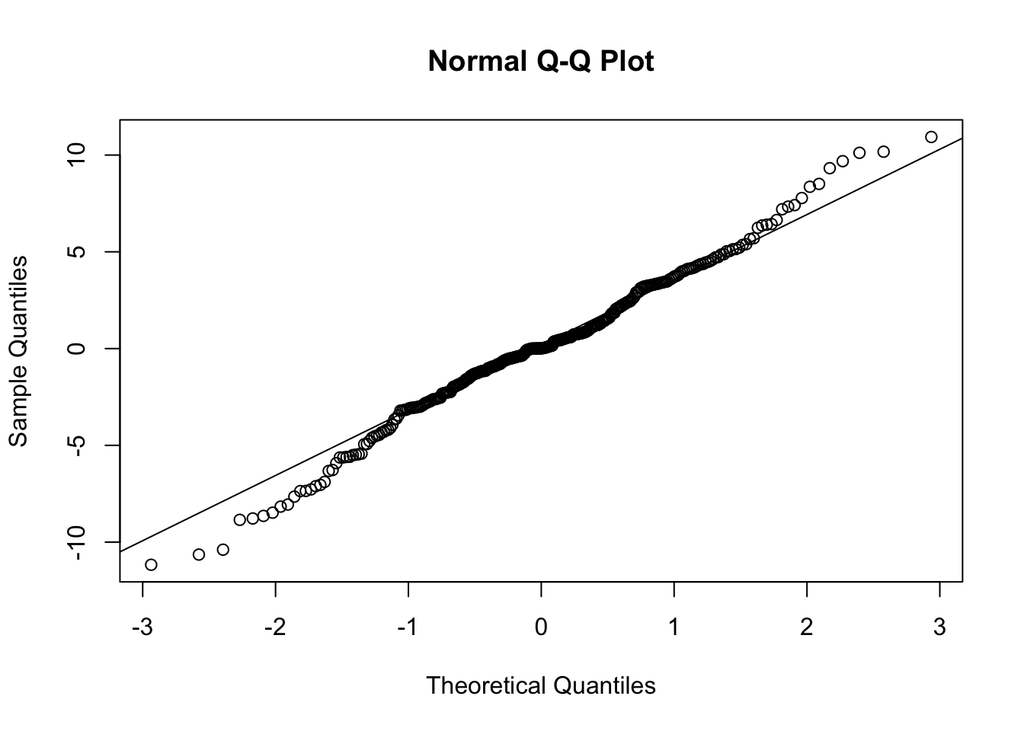

we can found that most of the residuals are on the qqline, it seems like satisfied the normal distribution.